# Video Game Sales

Author

Alayna Avila

Published

July 29, 2026

**TipGithub Repo Link**

[Github Repo Link](https://github.com/amavila7/Video_Game_Analysis.git)

## Overview

# Data & Research Questions

## Quality Check

Data summary

| Name | games |
| --- | --- |
| Number of rows | 50000 |
| Number of columns | 35 |
| _______________________ |  |
| Column type frequency: |  |
| character | 11 |
| numeric | 24 |
| ________________________ |  |
| Group variables | None |

**Variable type: character**

| skim_variable | n_missing | complete_rate | min | max | empty | n_unique | whitespace |
| --- | --- | --- | --- | --- | --- | --- | --- |
| game_id | 0 | 1 | 7 | 7 | 0 | 50000 | 0 |
| title | 0 | 1 | 5 | 35 | 0 | 1391 | 0 |
| platform | 0 | 1 | 2 | 17 | 0 | 33 | 0 |
| platform_type | 0 | 1 | 2 | 9 | 0 | 7 | 0 |
| platform_maker | 0 | 1 | 4 | 9 | 0 | 8 | 0 |
| genre | 0 | 1 | 4 | 16 | 0 | 20 | 0 |
| publisher | 0 | 1 | 4 | 22 | 0 | 51 | 0 |
| developer | 0 | 1 | 4 | 22 | 0 | 51 | 0 |
| publisher_region | 0 | 1 | 2 | 7 | 0 | 15 | 0 |
| publisher_tier | 0 | 1 | 2 | 5 | 0 | 3 | 0 |
| esrb_rating | 0 | 1 | 1 | 9 | 0 | 6 | 0 |

**Variable type: numeric**

| skim_variable | n_missing | complete_rate | mean | sd | p0 | p25 | p50 | p75 | p100 | hist |
| --- | --- | --- | --- | --- | --- | --- | --- | --- | --- | --- |
| platform_generation | 0 | 1 | 4.40 | 3.26 | 0.00 | 0.00 | 5.00 | 7.00 | 10.00 | ▇▅▅▆▃ |
| year | 0 | 1 | 2007.48 | 11.67 | 1985.00 | 1998.00 | 2008.00 | 2017.00 | 2026.00 | ▅▆▆▇▇ |
| metacritic_score | 0 | 1 | 74.05 | 8.63 | 37.00 | 68.00 | 74.00 | 80.00 | 99.00 | ▁▁▇▇▂ |
| user_score | 0 | 1 | 7.41 | 1.16 | 2.20 | 6.60 | 7.40 | 8.20 | 10.00 | ▁▁▅▇▃ |
| critic_review_count | 0 | 1 | 27.29 | 26.26 | 0.00 | 11.00 | 20.00 | 34.00 | 636.00 | ▇▁▁▁▁ |
| user_review_count | 0 | 1 | 470.61 | 894.57 | 0.00 | 91.00 | 221.00 | 515.00 | 39129.00 | ▇▁▁▁▁ |
| na_sales_million | 0 | 1 | 11.95 | 20.72 | 0.03 | 2.42 | 5.94 | 13.42 | 769.07 | ▇▁▁▁▁ |
| eu_sales_million | 0 | 1 | 7.73 | 13.48 | 0.01 | 1.51 | 3.76 | 8.63 | 389.10 | ▇▁▁▁▁ |
| jp_sales_million | 0 | 1 | 3.37 | 7.44 | 0.00 | 0.40 | 1.21 | 3.33 | 251.21 | ▇▁▁▁▁ |
| other_sales_million | 0 | 1 | 2.99 | 5.63 | 0.01 | 0.54 | 1.38 | 3.26 | 300.56 | ▇▁▁▁▁ |
| global_sales_million | 0 | 1 | 26.03 | 45.04 | 0.05 | 5.14 | 12.80 | 29.29 | 1494.68 | ▇▁▁▁▁ |
| estimated_revenue_million_usd | 0 | 1 | 639.16 | 1103.97 | 0.00 | 92.59 | 294.84 | 750.36 | 45686.50 | ▇▁▁▁▁ |
| launch_price_usd | 0 | 1 | 42.03 | 24.77 | 0.00 | 19.99 | 39.99 | 59.99 | 79.99 | ▆▃▅▇▆ |
| is_sequel | 0 | 1 | 0.41 | 0.49 | 0.00 | 0.00 | 0.00 | 1.00 | 1.00 | ▇▁▁▁▆ |
| online_multiplayer | 0 | 1 | 0.51 | 0.50 | 0.00 | 0.00 | 1.00 | 1.00 | 1.00 | ▇▁▁▁▇ |
| dlc_released | 0 | 1 | 0.62 | 0.48 | 0.00 | 0.00 | 1.00 | 1.00 | 1.00 | ▅▁▁▁▇ |
| microtransactions | 0 | 1 | 0.31 | 0.46 | 0.00 | 0.00 | 0.00 | 1.00 | 1.00 | ▇▁▁▁▃ |
| loot_boxes | 0 | 1 | 0.07 | 0.25 | 0.00 | 0.00 | 0.00 | 0.00 | 1.00 | ▇▁▁▁▁ |
| game_pass_available | 0 | 1 | 0.04 | 0.19 | 0.00 | 0.00 | 0.00 | 0.00 | 1.00 | ▇▁▁▁▁ |
| vr_support | 0 | 1 | 0.02 | 0.15 | 0.00 | 0.00 | 0.00 | 0.00 | 1.00 | ▇▁▁▁▁ |
| goty_nominated | 0 | 1 | 0.04 | 0.21 | 0.00 | 0.00 | 0.00 | 0.00 | 1.00 | ▇▁▁▁▁ |
| goty_won | 0 | 1 | 0.01 | 0.08 | 0.00 | 0.00 | 0.00 | 0.00 | 1.00 | ▇▁▁▁▁ |
| how_long_to_beat_main_hrs | 0 | 1 | 24.85 | 34.74 | 1.00 | 9.00 | 13.20 | 24.10 | 377.50 | ▇▁▁▁▁ |
| how_long_to_beat_completionist_hrs | 0 | 1 | 87.04 | 126.80 | 2.00 | 29.40 | 46.10 | 85.20 | 1685.00 | ▇▁▁▁▁ |

Summary

Data summary

| Name | games_cleaned |
| --- | --- |
| Number of rows | 50000 |
| Number of columns | 35 |
| _______________________ |  |
| Column type frequency: |  |
| character | 20 |
| numeric | 15 |
| ________________________ |  |
| Group variables | None |

**Variable type: character**

| skim_variable | n_missing | complete_rate | min | max | empty | n_unique | whitespace |
| --- | --- | --- | --- | --- | --- | --- | --- |
| game_id | 0 | 1 | 7 | 7 | 0 | 50000 | 0 |
| title | 0 | 1 | 5 | 35 | 0 | 1391 | 0 |
| platform | 0 | 1 | 2 | 17 | 0 | 33 | 0 |
| platform_type | 0 | 1 | 2 | 9 | 0 | 7 | 0 |
| platform_maker | 0 | 1 | 4 | 9 | 0 | 8 | 0 |
| genre | 0 | 1 | 4 | 16 | 0 | 20 | 0 |
| publisher | 0 | 1 | 4 | 22 | 0 | 51 | 0 |
| developer | 0 | 1 | 4 | 22 | 0 | 51 | 0 |
| publisher_region | 0 | 1 | 2 | 7 | 0 | 15 | 0 |
| publisher_tier | 0 | 1 | 2 | 5 | 0 | 3 | 0 |
| esrb_rating | 0 | 1 | 1 | 9 | 0 | 6 | 0 |
| is_sequel | 0 | 1 | 2 | 3 | 0 | 2 | 0 |
| online_multiplayer | 0 | 1 | 2 | 3 | 0 | 2 | 0 |
| dlc_released | 0 | 1 | 2 | 3 | 0 | 2 | 0 |
| microtransactions | 0 | 1 | 2 | 3 | 0 | 2 | 0 |
| loot_boxes | 0 | 1 | 2 | 3 | 0 | 2 | 0 |
| game_pass_available | 0 | 1 | 2 | 3 | 0 | 2 | 0 |
| vr_support | 0 | 1 | 2 | 3 | 0 | 2 | 0 |
| goty_nominated | 0 | 1 | 2 | 3 | 0 | 2 | 0 |
| goty_won | 0 | 1 | 2 | 3 | 0 | 2 | 0 |

**Variable type: numeric**

| skim_variable | n_missing | complete_rate | mean | sd | p0 | p25 | p50 | p75 | p100 | hist |
| --- | --- | --- | --- | --- | --- | --- | --- | --- | --- | --- |
| platform_generation | 0 | 1 | 4.40 | 3.26 | 0.00 | 0.00 | 5.00 | 7.00 | 10.00 | ▇▅▅▆▃ |
| year | 0 | 1 | 2007.48 | 11.67 | 1985.00 | 1998.00 | 2008.00 | 2017.00 | 2026.00 | ▅▆▆▇▇ |
| metacritic_score | 0 | 1 | 74.05 | 8.63 | 37.00 | 68.00 | 74.00 | 80.00 | 99.00 | ▁▁▇▇▂ |
| user_score | 0 | 1 | 7.41 | 1.16 | 2.20 | 6.60 | 7.40 | 8.20 | 10.00 | ▁▁▅▇▃ |
| critic_review_count | 0 | 1 | 27.29 | 26.26 | 0.00 | 11.00 | 20.00 | 34.00 | 636.00 | ▇▁▁▁▁ |
| user_review_count | 0 | 1 | 470.61 | 894.57 | 0.00 | 91.00 | 221.00 | 515.00 | 39129.00 | ▇▁▁▁▁ |
| na_sales_million | 0 | 1 | 11.95 | 20.72 | 0.03 | 2.42 | 5.94 | 13.42 | 769.07 | ▇▁▁▁▁ |
| eu_sales_million | 0 | 1 | 7.73 | 13.48 | 0.01 | 1.51 | 3.76 | 8.63 | 389.10 | ▇▁▁▁▁ |
| jp_sales_million | 0 | 1 | 3.37 | 7.44 | 0.00 | 0.40 | 1.21 | 3.33 | 251.21 | ▇▁▁▁▁ |
| other_sales_million | 0 | 1 | 2.99 | 5.63 | 0.01 | 0.54 | 1.38 | 3.26 | 300.56 | ▇▁▁▁▁ |
| global_sales_million | 0 | 1 | 26.03 | 45.04 | 0.05 | 5.14 | 12.80 | 29.29 | 1494.68 | ▇▁▁▁▁ |
| estimated_revenue_million_usd | 0 | 1 | 639.16 | 1103.97 | 0.00 | 92.59 | 294.84 | 750.36 | 45686.50 | ▇▁▁▁▁ |
| launch_price_usd | 0 | 1 | 42.03 | 24.77 | 0.00 | 19.99 | 39.99 | 59.99 | 79.99 | ▆▃▅▇▆ |
| how_long_to_beat_main_hrs | 0 | 1 | 24.85 | 34.74 | 1.00 | 9.00 | 13.20 | 24.10 | 377.50 | ▇▁▁▁▁ |
| how_long_to_beat_completionist_hrs | 0 | 1 | 87.04 | 126.80 | 2.00 | 29.40 | 46.10 | 85.20 | 1685.00 | ▇▁▁▁▁ |

Summary-2

## Research Questions

### Inferential

Do certain genres sell more than others?

Do multiplayer games increase sales?

How does microtransactions in a video game impact sales and launch price?

### Prediction

What features or characteristics of a game are most likely to win Game of the Year?

Which traits of a video game go into defining the launch price of the video game?

# Analysis

**Do certain genres sell more than others?**

As we see in Figure 1, every genre contains the whole range of launch prices which is `$0` (free) to `$79.99`. The different amount of games per range group of launch price for each genre are due to the difference in amount of games released per genre. With such a large imbalance of games per genre, it is difficult to decipher which genre of game is the most expense. Though it is worth noting how the majority of the games overall, tend to cost money. Another visual of launch price in relation to genre is Figure 3, where the spread of launch price for all the genres is easier to compare. The majority of the genres’ launch prices tend to be centered around `$40`, or `$50`. The spreads for all the genres appear pretty similar aside from `Rhythm` which has its middle `50%` on the higher end despite the median being `$40`. However, the range of prices does show how despite having a difference for location of the middle `50%` for `Rhythm` games, its worth noting how the overall range still covers the full range of launch prices. This means that few `Rhythm` games fall on the cheaper end of the launch price range (`$0-$30`).

Although launch price is helpful for gauging how much the game costs, prices do vary overtime. Therefore, to find the genre that sells the most, I looked at global sales Starting with global sales, Figure 2, shows how even genres with more games don’t always have the most sales. For instance, there are more games under `Action` (7,496) than under `Sports` (5,571), however, games under `Sports` tend to make more sales. In fact, `Sandbox` games appear to have a greater median for global sales than any other genre. `Visual Novel` is the genre with the lowest median and least spread for global sales.

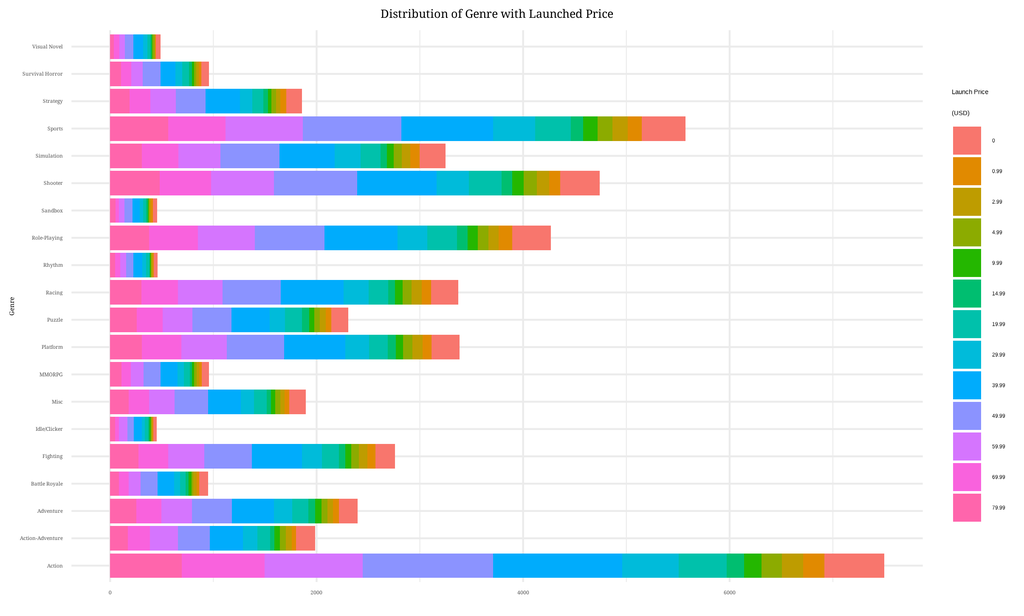

Figure 1: Genre with Launch Price Range

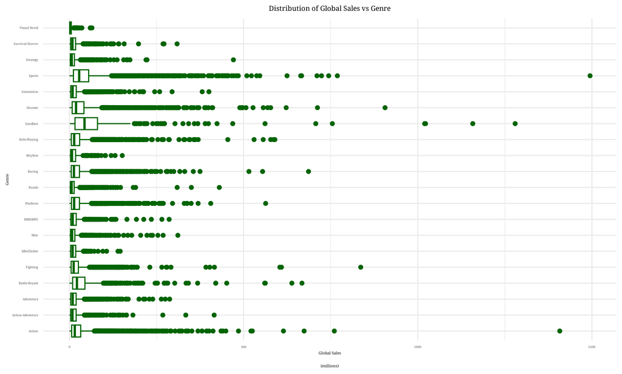

Figure 2: Global Sales vs Genre

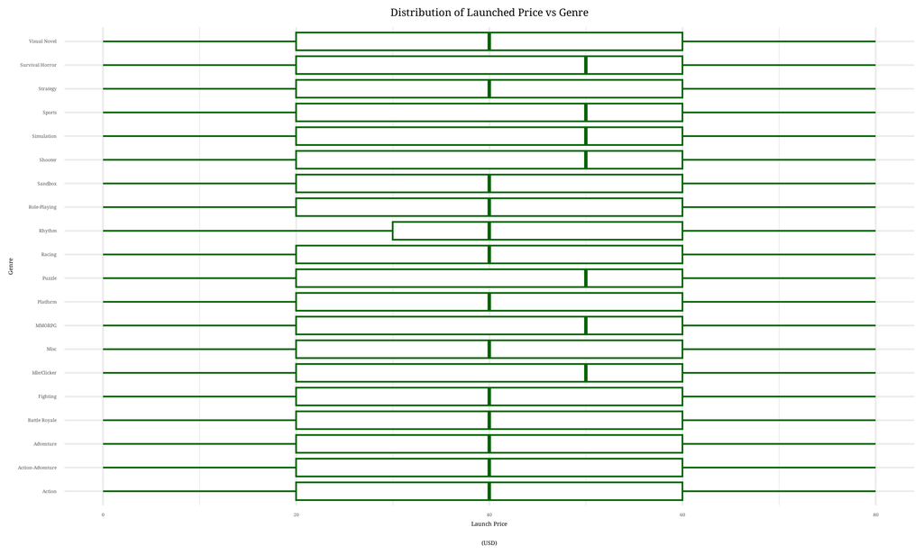

Figure 3: Launch Price vs Genre

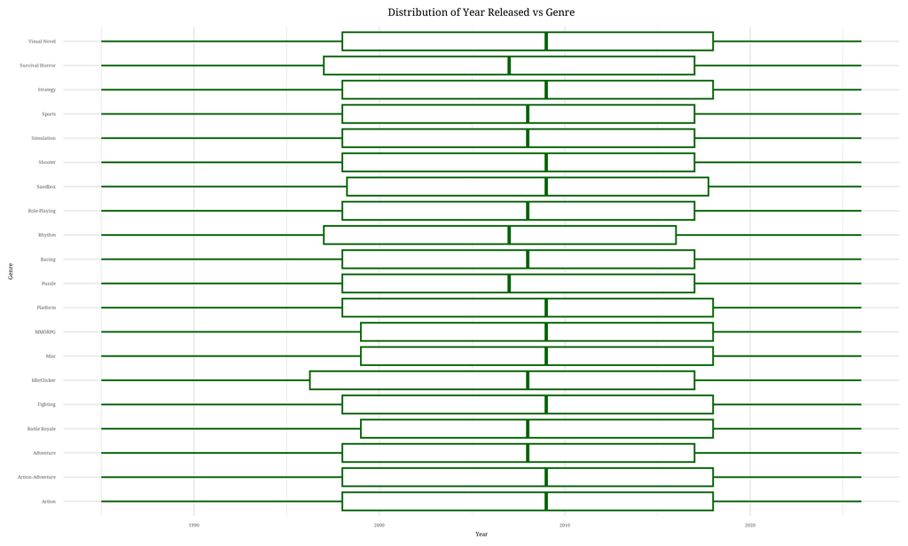

Figure 4: Year vs Genre

**Do online multiplayer games increase sales?**

Clearly whether or not the game is an online multiplayer, the games tend to sell pretty evenly when it comes to sales. However, online multiplayer games tend to have more sales overall. Therefore, online multiplayer as a feature for video games does tend to sell more.

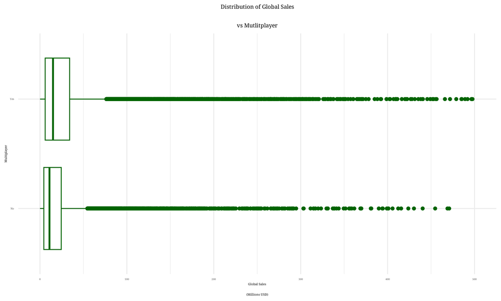

Figure 5: Global Sales vs Multiplayer

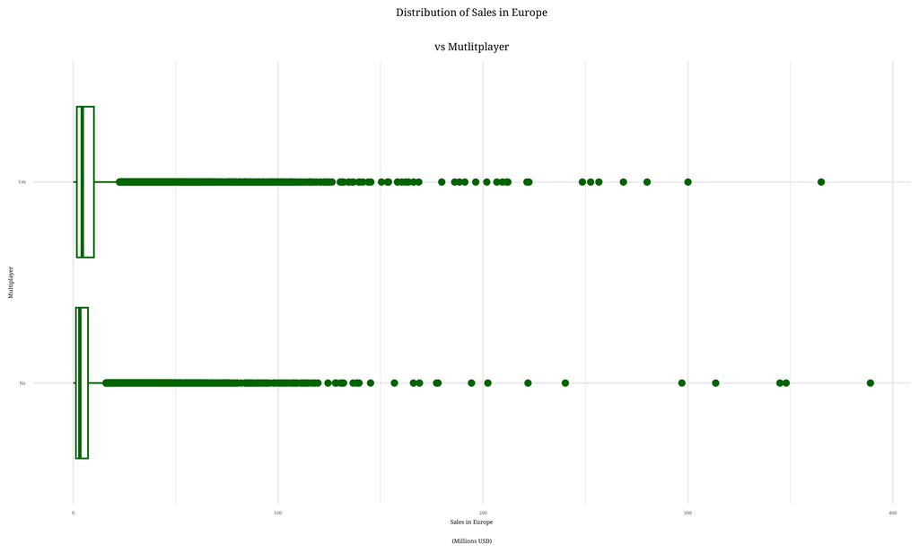

Figure 6: European Sales vs Multiplayer

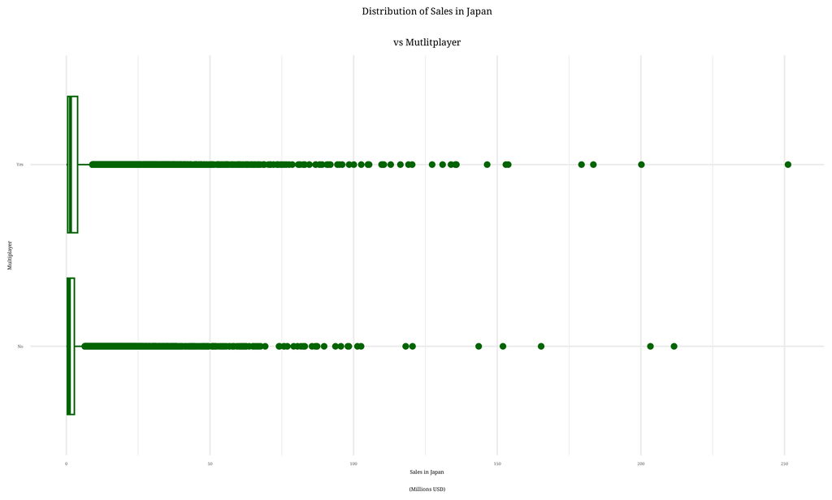

Figure 7: Japanese Sales vs Multiplayer

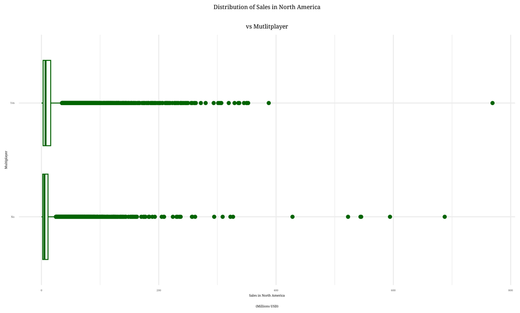

Figure 8: North American Sales vs Multiplayer

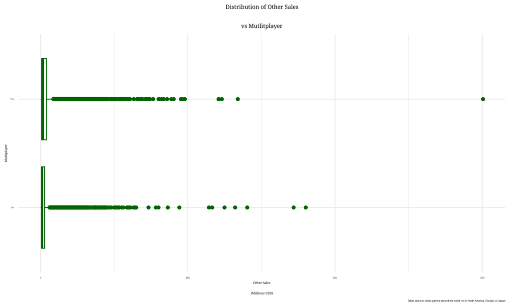

Figure 9: Other Sales vs Multiplayer

**How do microtransactions in a video game impact sales and launch price?**

Microtransactions may seem like an opportunity for players who enjoy pay-to-win games or even games that have a store for extra features. However, microtransactions are usually optional in games, it just might hinder the experience depending on what the player gets in return. Although microtransactions from the company’s side is another way to boost sales, especially for free games. Therefore, when looking at global sales for games and whether or not the game has microtransactions, Figure 10, shows how the sales for games with microtransactions is greater than those without. Although it is worth noting that the overall spread of sales among the games with and without the microtransactions do have similar spreads. The same conclusion can be drawn for specific continents as well, as seen in Figure 11, Figure 12, and Figure 13.

As for launch prices, most of the microtransactions tend to go with the games that have a launch price of `$20+`, and the games that are free. This isn’t too shocking since microtransactions can contribute to the sales of the video game on the business side, especially for the games that are launched as free. Although it is worth noting that the majority of the games don’t have microtransactions.

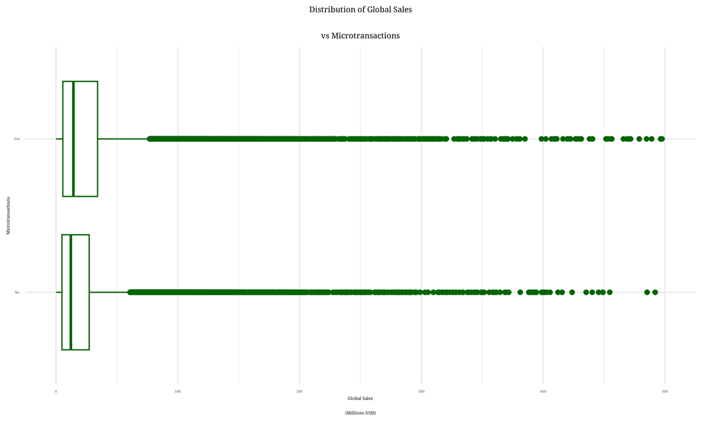

Figure 10: Global Sales vs Microtransactions

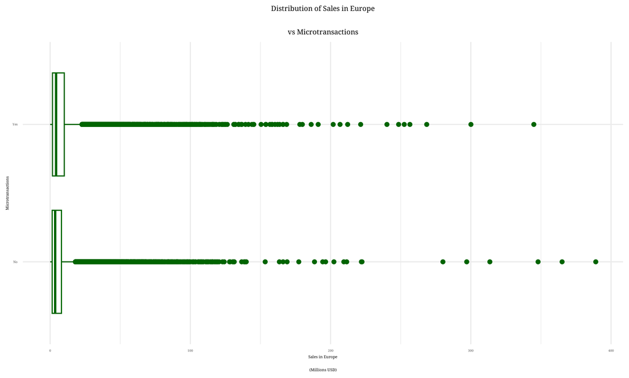

Figure 11: European Sales vs Microtransactions

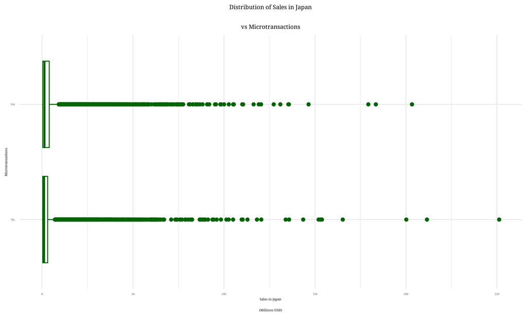

Figure 12: Japanese Sales vs Microtransactions

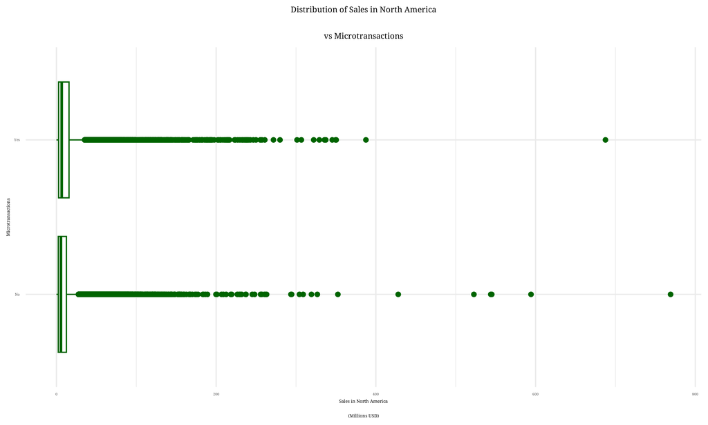

Figure 13: North American Sales vs Microtransactions

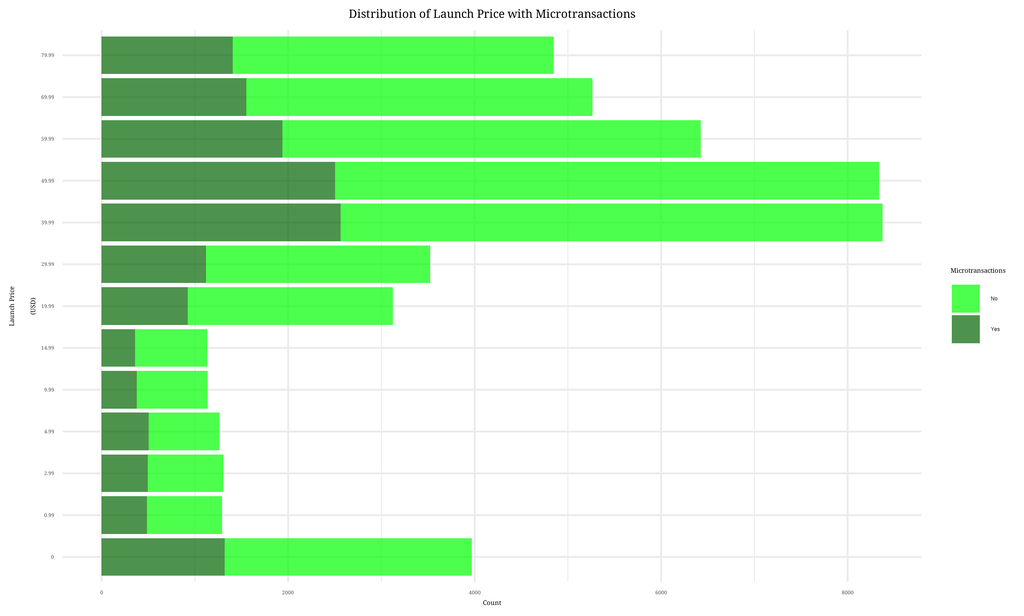

Figure 14: Launch Price with Microtransactions

# Additional Insight

Below are other figures I had created to satisfy my own curiosity. Beginning with Figure 15, we can see how not all the different platforms were around despite gaming being so popular. We can see how the genres for video games tend to favor `console` and `PC`, and how the other platforms didn’t come to be until the early `2000's` and `2010's`. During this time, the main platforms were `PC`, `console`, `browser` and `handheld`. We can also see how some platforms have gone away, likely due to being outdated, and how newer platforms take their place. As `handheld` and `browser` began to lose popularity, `mobile`, `hybrid`, and `streaming` platforms came to be. This occurs around the late `2010's` and early `2020's` for all the genres. (Figure 16, shows a more clear timeline of the platforms)Popularity of platforms over the years, especially for genres is good to know for when companies want to produce a video game, and not all the platforms are options. For instance, if I had a `browser` game in the early `2020's`, I wouldn’t have as big of an audience, if any, as I would if I were to make the `browser` game a `streaming` game.

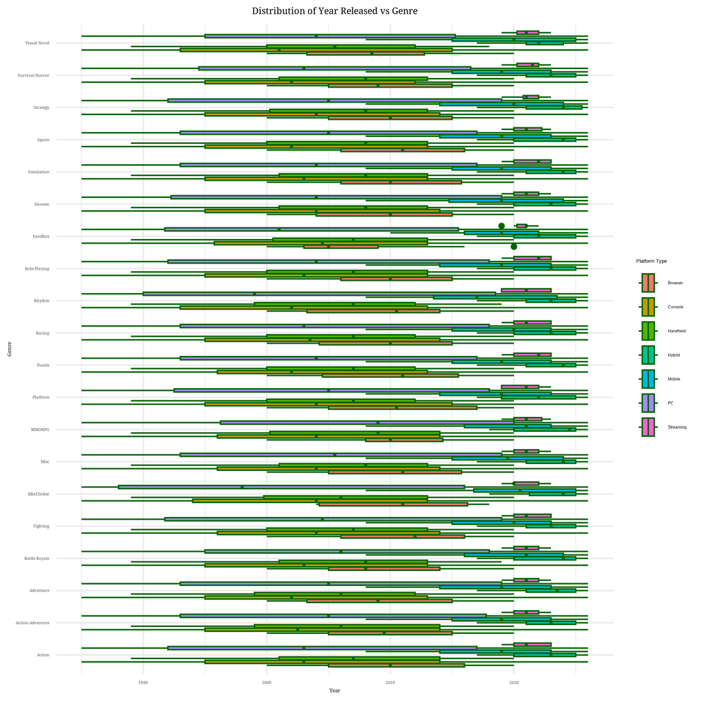

Figure 15: Year vs Genre with Platform Type

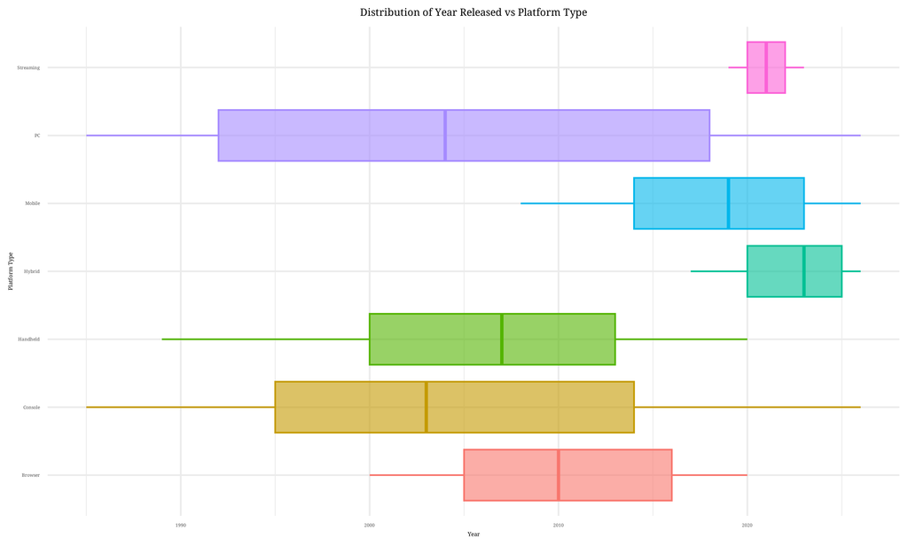

Figure 16: Year Released vs Platform Type

Shifting gears a bit, aside from popularity of platforms and genres, the length of the video game can also say a lot about the game and the goal it serves. Longer games tend to have more in depth stories, where shorter ones are more for immediate dopamine rushes from completing an action. Although if a game is longer, the difference between main story completed vs completion of the game and all of the achievements grows larger. As we see in Figure 17, usually the longer games take longer to complete the whole game than just the main story. As for the impact of launch price, the launch price doesn’t seem to define the length of the game, rather any length can be charged for any launch price. As for the platform type, Figure 18, shows how the longer games tend to be on `console` or `PC`, yet the longest game is on `hybrid`. As seen in both of these figures, the main story can be completed within `1/3` of the time that it takes to complete the full game, based on the scaling for the axes alone.

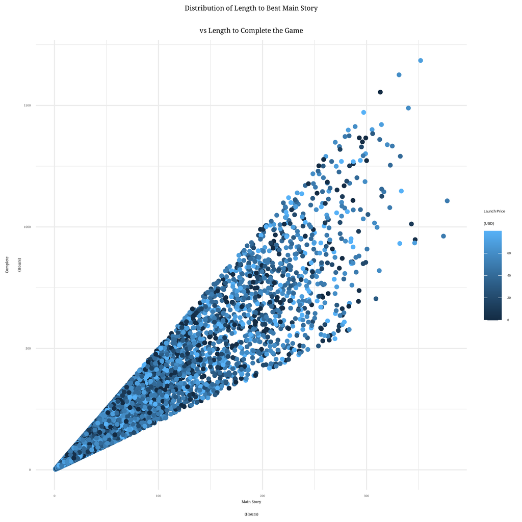

Figure 17: Main Hours vs Completion Hours with Launch Price

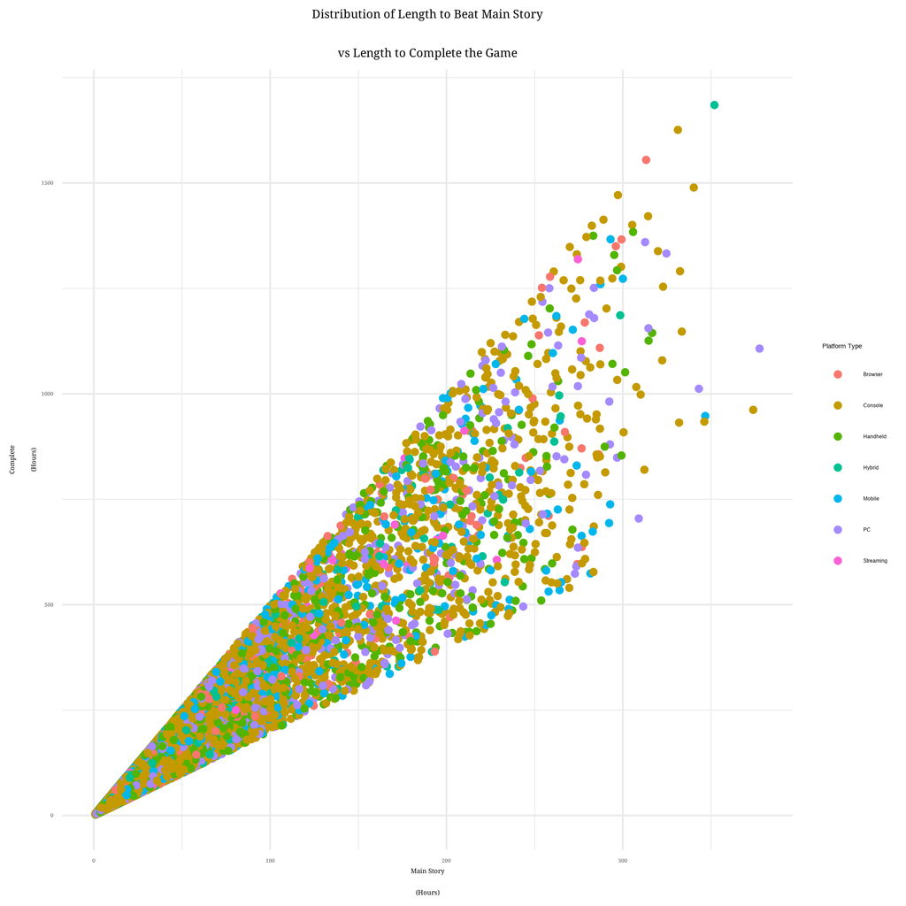

Figure 18: Main Hours vs Completion Hours with Platform Type

Another shocking find was how different the estimated revenue was to the global sales. Figure 19 shows that games with higher launch prices were estimated to have greater revenue than the actual global sales show. In fact, the games that were launched at `$0` (free) or less than `$20`, had greater global sales than estimated revenue. While sales and revenue aren’t the same, the global sales do play a role in how much revenue the developers or company receives.

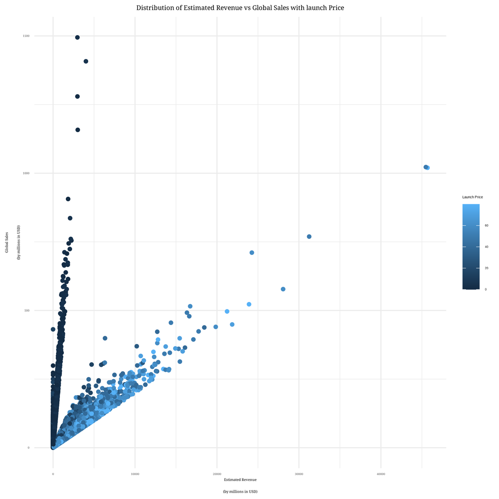

Figure 19: Estimated Revenue vs Global Sales with Launch Price

# Reflection

- I wish the month was recorded in the data set
- I wish online was separated from multiplayer
- It would be nice if how many players allowed per game (1,2,3,4, etc)

## References

GeeksforGeeks. “Bootstrap Method.” GeeksforGeeks, July 23, 2025.

[GeeksforGeeks](https://www.geeksforgeeks.org/maths/bootstrap-method/) was really helpful for conceptually understanding the bootstrap method. It provided clear mini examples of the process.